# COVID19 - Forecast and predictions using a time dependent SEIR model

Paolo Girardi

15 Marzo, 2020

This work is licensed under a [Creative Commons Attribution-NonCommercial 4.0 International License](http://creativecommons.org/licenses/by-nc/4.0/).

# Disclaimer

- We want to investigate the evolution of the coronavirus pandemic in Italy from a statistical perspective using aggregated data.
- Our point of view is that of surveillance with the goal of detecting important changes in the underlying (random) process as soon as possible after it has occured.
- We use data provided by Italian Civil Protection Department
- This document is in a draft mode, and it is continuously updated.
- The layout of the draft must definitely be improved.

## The COVID dataset

The present analysis started from the dataset on COVID19 updated in https://github.com/pcm-dpc/COVID-19, database provided by the Italian Civil Protection.

# Software

Install packages `dygraphs`, `xts` and `EpiDynamics` if not available

```r
checkpackage <- function(package) {
  if (!package %in% installed.packages()) install.packages(package)
}
checkpackage("dygraphs")
checkpackage("xts")
checkpackage("EpiDynamics")
```

and load them.

# Source of the data

Download the data from

https://github.com/pcm-dpc/COVID-19/

# Results

## Load dataset

```
## [1] 20
```

Several outcomes can be potentially monitored, that is

```
##  [1] "ricoverati_con_sintomi"      "terapia_intensiva"
##  [3] "totale_ospedalizzati"        "isolamento_domiciliare"
##  [5] "totale_attualmente_positivi" "nuovi_attualmente_positivi"
##  [7] "dimessi_guariti"             "deceduti"
##  [9] "totale_casi"                 "tamponi"
```

It is worth noting that some outcomes present negative counts in some regions. It looks like some of these negative counts are redesignations. Outcomes presenting negative values cannot be analyzed using the proposed model.

Then we extract the timeseries.

[interactive chart not shown]

### The S(E)IR model (to be revised)

With the aim of predicting the future number of COVID19 cases on the basis of the actual data, we used a SEIR model applied to the COVID19 epidemic in Italy.

We will consider the classical [SIR model](https://en.wikipedia.org/wiki/Compartmental_models_in_epidemiology) [@Kermack1927].

The model divides a population of hosts into three classes: susceptible, infected, recovered. The model describes how the portion of the population in each of these classes changes with time. Births are modeled as flows from “elsewhere” into the susceptible class; deaths are modeled as flows from the $S$, $I$, or $R$ compartment into “elsewhere”. If $S$, $I$, and $R$ refer to the numbers of individuals in each compartment, then these **state variables** change according to the following system of differential equations:
$$\begin{aligned}
\frac{d}{dt}S(t) &= B(t)-\lambda\,S(t)-\mu\,S(t)\\
\frac{d}{dt}I(t) &= \lambda\,S(t)-\gamma\,I(t)-\mu\,I(t)\\
\frac{d}{dt}R(t) &= \gamma\,I(t)-\mu\,R(t).\\
\end{aligned}$$
Here, $B$ is the crude birth rate (births per unit time), $\mu$ is the death rate and $\gamma$ is the recovery rate. We’ll assume that the force of infection, $\lambda$, for a constant population $N$
$$\lambda = \beta\,\frac{I}{N},$$
so that the risk of infection a susceptible faces is proportional to the *prevalence* (the fraction of the population that is infected). This is known as the assumption of frequency-dependent transmission.

# The reproduction number of COVID19.

The number of infected individuals $I$ at time $t$ is approximately
$$I(t)\;\approx\;I_0\,e^{R_0\,(\gamma+\mu)\,t}$$
where $I_0$ is the (small) number of infectives at time $0$, $\frac{1}{\gamma}$ is the infectious period, and $\frac{1}{\mu}$ is the host lifespan.

$R_0$ is the reproduction number (https://en.wikipedia.org/wiki/Basic_reproduction_number) and indicates how contagious an infectious disease is.

Taking logs of both sides, we get

$$\log{I}(t)\;\approx\;\log{I_0}+(R_0)\,(\gamma+\mu)\,t,$$
which implies that a semi-log plot of $I$ vs $t$ should be approximately linear with a slope proportional to $R_0$ and the recovery rate.

[interactive chart not shown]

We estimate the $R_0$ parameter in the linear model.

$$\log(I(t))= \alpha + \beta t +e_t$$

The estimated slope coefficient $\hat\beta$ is used to estimate $R_0$ as in the following formula:

$$\widehat\beta=(\widehat{R_0})\,(\gamma+\mu)$$
The parameter $\mu$<<$\gamma$ and it can not be considered. As consequence, R0 can be estimated as follows
$$\hat{R_0}=\frac{\hat{\beta}}{\gamma}$$

The incubation period $1/ \gamma$ for the coronavirus is in mean 5.1 days with a range from 2-14 days. Please see https://www.worldometers.info/coronavirus/coronavirus-incubation-period/. However, the incubation period is used for epidemic diseases that causes the immediate home isolation of infected subjects.

In the calculation we considered an “incubation period” of 14 days for two reasons:  
1) the majority of cases is asymptomatic, contagiousness is greater than 5, maybe 14. A minority (who made the swab) will have a duration of about 5 days between the start of contagiousness and swab; 2) 14 days is the worst scenario because in this period low impact COVID19 symptoms can be confused with the concomitant FLU epidemic (https://www.webmd.com/lung/news/20200310/know-the-symptoms-of-covid19).

We calculate several R0 values, each one based on a mobile window of 5 days, that can be sufficient to estimate a local trend, in order to assess if the R0 trend is decreasing (how is expected to be).

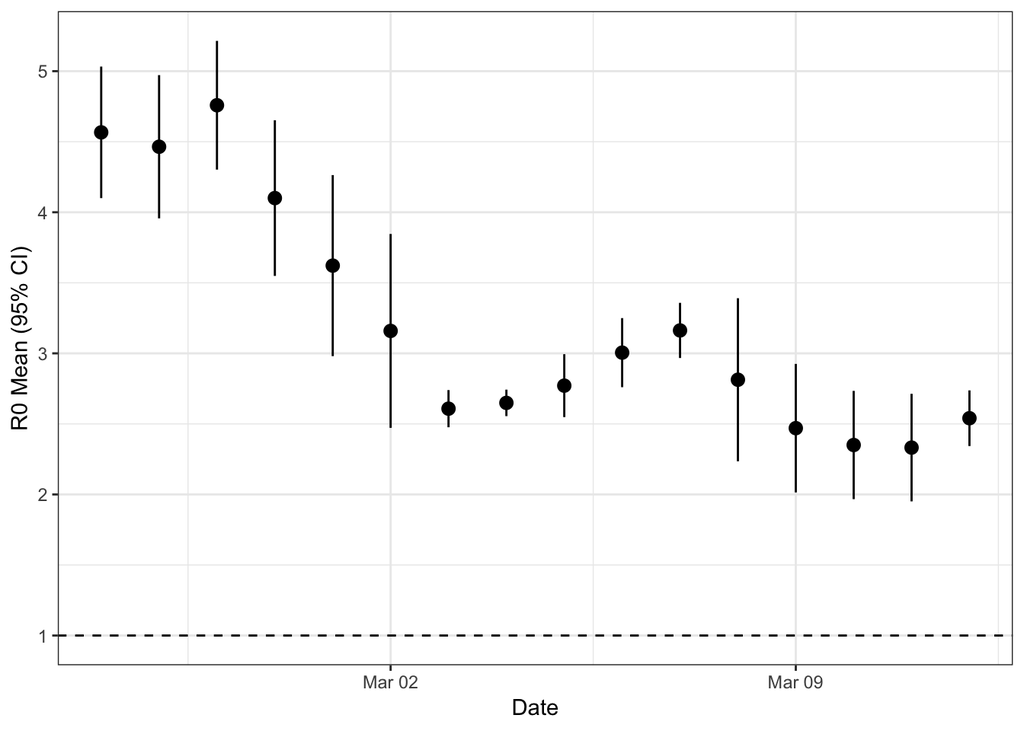

The R0 shows a decreasing trend in the last period. We use the estimated trend between R0 and time to calculate the future R0 value for the next 14 days. We predict beta (and R0) for the next 14 days assuming a Gamma distribution for the beta (the slope) forcing its value to be greater than 0. The trend was not monotonic, we use a simple splines to increase the fitting of the model to the data.

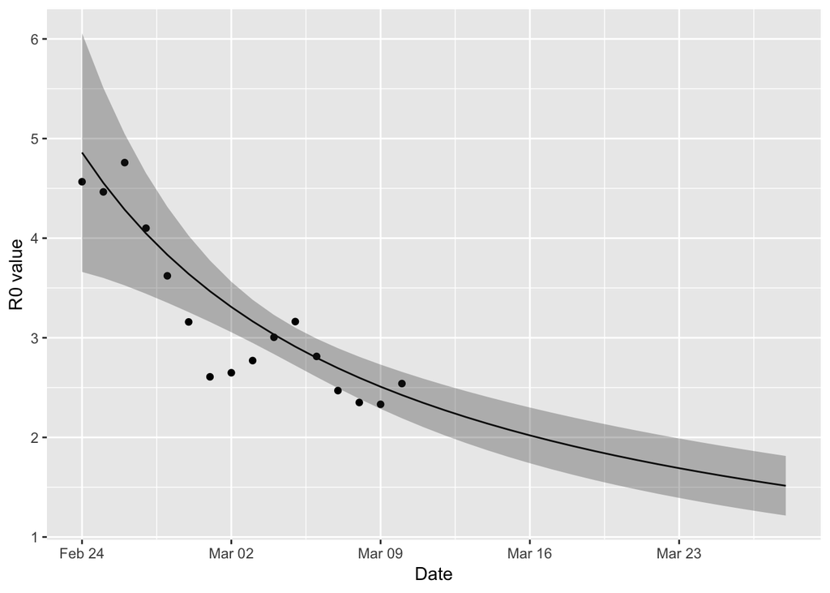

R0 passes from a value of 4.57 in the initial phase to an estimated value of 1.51 at the ending of the 14-days forecast.

We want to make a short term forecast (14 days) with 3 scenario, based on the number of exposed people:

-Scenario 1: 10 exposed people for each COVID-19 case (no home restrictions made or even no effects)

-Scenario 2: 5 exposed people for each COVID-19 case (-50% exposed people)

-Scenario 3: 3 exposed people for each COVID-19 case (-70% exposed people)

and parameters:  
- beta: the quantity connected to R0 is considered to vary according the previous estimation  
- gamma= 1/duration (rate of infection duration of COVID-19, 14 days)  
- sigma0: the coronavirus transmission rate (half of flu epidemic)  
- mu0: the overall mortality rate

```r
# initial number of infectus
I0<-dat_csv$totale_attualmente_positivi[dim(dat_csv)[1]]; I0
```

```
## [1] 17750
```

```r
# initial number of recovered
R0<-dat_csv$dimessi_guariti[dim(dat_csv)[1]]; R0
```

```
## [1] 1966
```

```r
# italian poulation
N=60480000
# duration of COVID19
duration<-14
#sigma0 is the coronavirus transmission rate fixed to 5%  (half of flu epidemic)
sigma0<-0.05
#mortality rate
mu0<-1/(82*365.25) # 1/lifespan
```

We use the library(EpiDynamics) and the function SEIR() to implement a SEIR model:

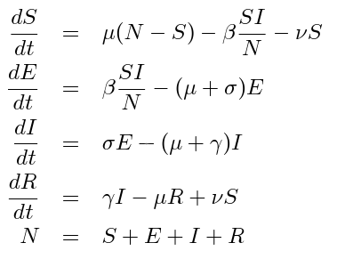

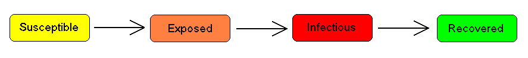

where the parameter beta here is time dependent, as estimated before by the gamma regression model.

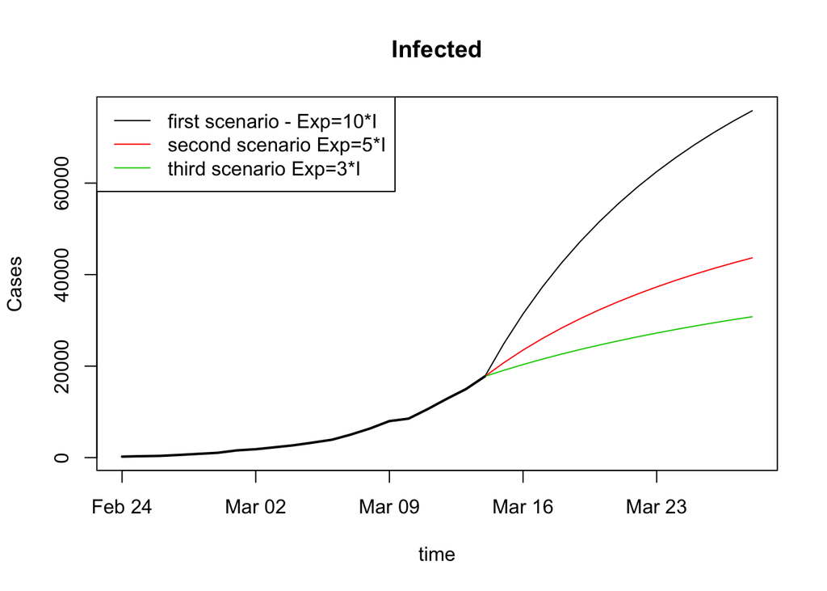

```r
library(EpiDynamics)

# average number of single connections of an infected person
# less contacts, less probability of new infections
# we keep constant the other parameters
forecast<-14
seir1<-seir2<-seir3<-NULL
for(i in 1:forecast){
parameters <- c(mu = mu0, beta = beta.predict$fit[days+i], sigma = sigma0, gamma = 1/duration)
f1<-10
if( i==1) initials <- c(S = 0.95, E = (f1*I0/N), I = I0/N, R = R0/N)
if( i>1) initials <- c(S = seir1_temp$results$S[2], E = seir1_temp$results$E[2], I =seir1_temp$results$I[2], R = seir1_temp$results$R[2])
seir1_temp <- SEIR(pars = parameters, init = initials, time = 0:1)
seir1 <- rbind(seir1,SEIR(pars = parameters, init = initials, time = 0:1)$results[2,])
f2<-5
if( i==1) initials <- c(S = 0.95, E = (f2*I0/N), I = I0/N, R = R0/N)
if( i>1) initials <- c(S = seir2_temp$results$S[2], E = seir2_temp$results$E[2], I =seir2_temp$results$I[2], R = seir2_temp$results$R[2])
seir2_temp <- SEIR(pars = parameters, init = initials, time = 0:1)
seir2 <- rbind(seir2,SEIR(pars = parameters, init = initials, time = 0:1)$results[2,])
f3<-3
if( i==1) initials <- c(S = 0.95, E = (f3*I0/N), I = I0/N, R = R0/N)
if( i>1) initials <- c(S = seir3_temp$results$S[2], E = seir3_temp$results$E[2], I =seir3_temp$results$I[2], R = seir3_temp$results$R[2])
seir3_temp <- SEIR(pars = parameters, init = initials, time = 0:1)
seir3 <- rbind(seir3,SEIR(pars = parameters, init = initials, time = 0:1)$results[2,])
}

date<-seq(as.Date("2020-02-24"),as.Date("2020-02-24")+forecast-1+dim(dat_csv)[1],1)
plot(date,c(dat_csv$totale_attualmente_positivi,seir1$I*N),type="l",ylab="Cases",xlab="time",main="Infected")
lines(date,c(dat_csv$totale_attualmente_positivi,seir2$I*N),col=2)
lines(date,c(dat_csv$totale_attualmente_positivi,seir3$I*N),col=3)
lines(date[1:dim(dat_csv)[1]],dat_csv$totale_attualmente_positivi,lwd=2)
legend("topleft",c("first scenario - Exp=10*I","second scenario Exp=5*I","third scenario Exp=3*I"),lty=1,col=1:3)
```

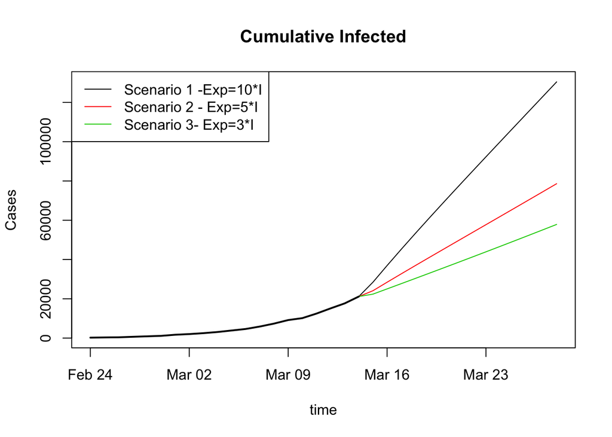

```r
plot(date,c(dat_csv$totale_casi,(seir1$I+seir1$R)*N),type="l",ylab="Cases",xlab="time",main="Cumulative Infected")
lines(date,c(dat_csv$totale_casi,(seir2$I+seir2$R)*N),col=2)
lines(date,c(dat_csv$totale_casi,(seir3$I+seir3$R)*N),col=3)
lines(date[1:dim(dat_csv)[1]],(dat_csv$totale_casi),lwd=2)
legend("topleft",c("Scenario 1 -Exp=10*I","Scenario 2 - Exp=5*I","Scenario 3- Exp=3*I"),lty=1,col=1:3)
```

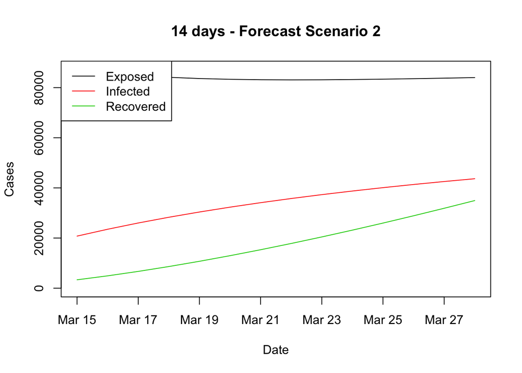

```r
plot(date[(days+1):(days+forecast)],seir2$E*N,type="l",ylab="Cases",xlab="Date",main="14 days - Forecast Scenario 2",ylim=c(0,max(seir2$E*N,seir2$I*N,seir2$R*N )))
lines(date[(days+1):(days+forecast)],seir2$I*N,col=2)
lines(date[(days+1):(days+forecast)],seir2$R*N,col=3)
legend("topleft",c("Exposed","Infected","Recovered"),lty=1,col=1:4)
```